# Coursera Machine Learning Project

Denis Rasulev

December 2015

# Introduction

The goal of the project is to build a model that will predict the manner in which excersize is done using the data from accelerometers on the belt, forearm, arm and a dumbell collected from six participants.

# Setup and Prepare

```r
# Load required packages
library(caret)
library(e1071)
library(randomForest)

# set seed for reproducible results
set.seed(2015)

# read in our data
trn <- read.csv("pml-training.csv")
tst <- read.csv("pml-testing.csv")
```

# Data Exploration

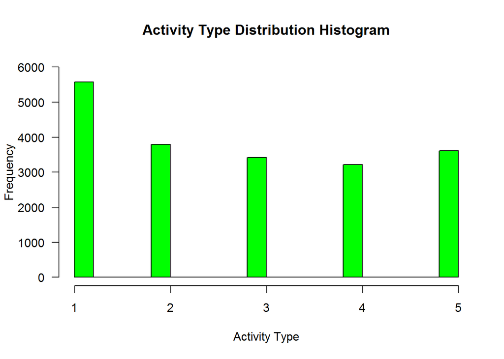

```r
str(trn)
head(trn)
summary(trn)

# build the histogram to see the distribution of 'classe' variable obseravations
hist(as.numeric(trn$classe),
     main = "Activity Type Distribution Histogram",
     xlab = "Activity Type",
     col = "green",
     ylim = c(0, 6000),
     las = 1)
```

```r
# how many complete cases do we have?
sum(complete.cases(trn))
```

```
## [1] 406
```

# Data Cleaning

After some research, we can see that several variables mostly contain useless data: missing values, i.e. “”, ‘NA’ values and ‘#DIV/0!’ values and number of such observations is very significant. To make data clean and tidy we will remove such variables that contain more than 50% of useless data. Otherwise we could possibly impute missing values to get more precise model (if needed).

```r
del <- numeric() # vector of variables to be removed
mar <- nrow(trn) * 0.5 # margin to cut off variables. 0.5 = 50%

# if total number of useless observations is more than 50% then add such variable to the removal list 'del'
for(i in 1:length(trn)) {
    if ( sum(trn[i] == "") || sum(is.na(trn[i])) || sum(trn[i] == "#DIV/0!") > mar ) {
        del <- c(del, i)
    }
}

# make clean data set without variables with more than 50% of useless data
trn <- trn[,-del]

# there are also some descriptive variables (first 7), which we do not need to build our predictive model, so we remove them also
trn <- trn[,-c(1:7)]

# clean dataset specs
str(trn, list.len = 0)
```

```
## 'data.frame':    19622 obs. of  53 variables:
##   [list output truncated]
```

Now we have clean and tidy data set with 53 variables only. We need to make same changes to our testing dataset.

```r
# process testing dataset the same way
tst <- tst[,-del]
tst <- tst[,-c(1:7)]
str(tst, list.len = 0)
```

```
## 'data.frame':    20 obs. of  53 variables:
##   [list output truncated]
```

# Training and Validation

We have a classification task here and to solve it, we’ll use Random Forest method, which handles such cases very well. For this we need to split our training data into training and validation sets at the ratio of 75-25.

```r
split <- createDataPartition(trn$classe, p = 0.75, list = FALSE)
training <- trn[split,]
validate <- trn[-split,]
```

Now we build and train our model using training set. We’ve made 5-fold cross-validation, which is more than enough here, however it takes a while to finish.

```r
model <- train( classe ~ .,
                data = training,
                method = "rf",
                trControl = trainControl(method = "cv", number = 5),
                prox = TRUE,
                allowParallel = TRUE)
print(model)
```

```
## Random Forest
##
## 14718 samples
##    52 predictor
##     5 classes: 'A', 'B', 'C', 'D', 'E'
##
## No pre-processing
## Resampling: Cross-Validated (5 fold)
## Summary of sample sizes: 11774, 11774, 11775, 11775, 11774
## Resampling results across tuning parameters:
##
##   mtry  Accuracy   Kappa      Accuracy SD   Kappa SD
##    2    0.9912353  0.9889114  0.0008453422  0.001070666
##   27    0.9906921  0.9882246  0.0038092835  0.004819659
##   52    0.9844415  0.9803176  0.0051238711  0.006481495
##
## Accuracy was used to select the optimal model using  the largest value.
## The final value used for the model was mtry = 2.
```

Now let’s check how good our model is.

```r
# use our model to predict 'classe' variable in validation dataset
prediction <- predict(model, validate[,-53])

# and check how well our prediction works
confusionMatrix(prediction, validate$classe)
```

```
## Confusion Matrix and Statistics
##
##           Reference
## Prediction    A    B    C    D    E
##          A 1394    6    0    0    0
##          B    0  942   12    0    0
##          C    0    1  843   19    0
##          D    0    0    0  783    1
##          E    1    0    0    2  900
##
## Overall Statistics
##
##                Accuracy : 0.9914
##                  95% CI : (0.9884, 0.9938)
##     No Information Rate : 0.2845
##     P-Value [Acc > NIR] : < 2.2e-16
##
##                   Kappa : 0.9892
##  Mcnemar's Test P-Value : NA
##
## Statistics by Class:
##
##                      Class: A Class: B Class: C Class: D Class: E
## Sensitivity            0.9993   0.9926   0.9860   0.9739   0.9989
## Specificity            0.9983   0.9970   0.9951   0.9998   0.9993
## Pos Pred Value         0.9957   0.9874   0.9768   0.9987   0.9967
## Neg Pred Value         0.9997   0.9982   0.9970   0.9949   0.9998
## Prevalence             0.2845   0.1935   0.1743   0.1639   0.1837
## Detection Rate         0.2843   0.1921   0.1719   0.1597   0.1835
## Detection Prevalence   0.2855   0.1945   0.1760   0.1599   0.1841
## Balanced Accuracy      0.9988   0.9948   0.9905   0.9868   0.9991
```

```r
# now we use our model to predict 'classe' variable in our testing data set.
answers <- predict(model, tst)
answers
```

```
##  [1] B A B A A E D B A A B C B A E E A B B B
## Levels: A B C D E
```

We have predicted all values, using our model.

```r
# write all answers to text files for submission.
pml_write_files = function(x) {
    n = length(x)
    for(i in 1:n) {
        filename = paste0("problem_id_", i, ".txt")
        write.table(x[i], file = filename, quote = FALSE, row.names = FALSE, col.names = FALSE)
    }
}
pml_write_files(answers)
```

We’ve written our predictions to text files and uploaded them to Coursera site. All predictions appeared to be correct.

# Conclusion

Random Forest method proved to be chosen correctly for this case as prediction model built with it showed very good accuracy of about 99%. All test cases were classified correctly and passed Coursera site check.